# Federated Imputation

Thom Volker

Utrecht University

15-07-2020

# 1 Previous results

Without partitioning the data, we already saw that synthesizing does not distort the relationships of the variables in the data at hand. That is, synthesizing a dataset results in $M$ synthetic datasets with, on average, the same properties as the original dataset. The results can be seen in the following table. This table contains the simulation results of synthesizing multivariate normally distributed data, where the correlation between predictors equals $\rho = 0$, the proportion explained variance equals $R^2 = .50$ and the sample size equals $n = 100$. Note that synthesizing is done by means of the default settings (by means of CART), and the variance of the estimates is calculated as
$$Var(\beta) = \bar{v}_{M}(1 + \frac{1}{M}),$$
where $\bar{v}_M$ is the average variance of the regression coefficient over the $M$ synthetic datasets.

| Method | Variable | Population estimate | Qbar | Bias | MeanSE | MinSE | MaxSE | Lower | Upper | CIW | Coverage |
| --- | --- | --- | --- | --- | --- | --- | --- | --- | --- | --- | --- |
| Real_Sample | IV1 | 0.000 | 0.003 | 0.003 | 0.072 | 0.050 | 0.101 | -0.139 | 0.144 | 0.283 | 0.950 |
| Real_Sample | IV2 | 0.316 | 0.318 | 0.002 | 0.072 | 0.053 | 0.104 | 0.177 | 0.459 | 0.281 | 0.943 |
| Real_Sample | IV3 | 0.632 | 0.635 | 0.002 | 0.072 | 0.050 | 0.098 | 0.494 | 0.775 | 0.281 | 0.959 |
| Syn10 | IV1 | 0.000 | 0.003 | 0.003 | 0.079 | 0.055 | 0.110 | -0.152 | 0.158 | 0.309 | 0.950 |
| Syn10 | IV2 | 0.316 | 0.291 | -0.025 | 0.079 | 0.057 | 0.111 | 0.137 | 0.445 | 0.308 | 0.922 |
| Syn10 | IV3 | 0.632 | 0.607 | -0.026 | 0.078 | 0.054 | 0.105 | 0.453 | 0.760 | 0.307 | 0.950 |

# 2 Results with partitioned data and uncorrelated predictors

## 2.1 CART Synthesizing method

CART Method: First variable is sampled from the observed data, the second variable is predicted from the first variable by means of a regression tree, the third variable is predicted from the first two variables, and so on.

When we first partition the sampled data from the multivariate normal distribution, the results change to quite some extent, which can be seen in the following table. The coverage seems to be very low, and far below the nominal level of $95\%$.

Results of a linear regression model where DV is regression on the predictors IV1, IV2 and IV3, with the values sampled directly from the population in the first three rows, and the synthesized data by means of CART with M = 10 in the last three rows with partitioned data.

| Sample size | Method | Variable | Population estimate | Qbar | Bias | MeanSE | MinSE | MaxSE | Lower | Upper | CIW | Coverage |
| --- | --- | --- | --- | --- | --- | --- | --- | --- | --- | --- | --- | --- |
| n = 100 | Real_Sample | IV1 | 0.000 | 0.003 | 0.003 | 0.072 | 0.050 | 0.101 | -0.139 | 0.144 | 0.283 | 0.950 |
| n = 100 | Real_Sample | IV2 | 0.316 | 0.318 | 0.002 | 0.072 | 0.053 | 0.104 | 0.177 | 0.459 | 0.281 | 0.943 |
| n = 100 | Real_Sample | IV3 | 0.632 | 0.635 | 0.002 | 0.072 | 0.050 | 0.098 | 0.494 | 0.775 | 0.281 | 0.959 |
| n = 100 | Syn | IV1 | 0.000 | 0.002 | 0.002 | 0.091 | 0.065 | 0.123 | -0.176 | 0.179 | 0.356 | 0.965 |
| n = 100 | Syn | IV2 | 0.316 | 0.213 | -0.103 | 0.091 | 0.069 | 0.129 | 0.035 | 0.391 | 0.356 | 0.808 |
| n = 100 | Syn | IV3 | 0.632 | 0.472 | -0.160 | 0.090 | 0.064 | 0.118 | 0.295 | 0.649 | 0.354 | 0.592 |
| n = 1000 | Real_Sample | IV1 | 0.000 | -0.001 | -0.001 | 0.022 | 0.020 | 0.025 | -0.044 | 0.043 | 0.088 | 0.952 |
| n = 1000 | Real_Sample | IV2 | 0.316 | 0.317 | 0.001 | 0.022 | 0.020 | 0.025 | 0.273 | 0.361 | 0.088 | 0.952 |
| n = 1000 | Real_Sample | IV3 | 0.632 | 0.633 | 0.001 | 0.022 | 0.020 | 0.025 | 0.589 | 0.677 | 0.088 | 0.942 |
| n = 1000 | Syn | IV1 | 0.000 | 0.000 | 0.000 | 0.024 | 0.022 | 0.027 | -0.047 | 0.047 | 0.094 | 0.947 |
| n = 1000 | Syn | IV2 | 0.316 | 0.301 | -0.015 | 0.024 | 0.022 | 0.027 | 0.254 | 0.348 | 0.094 | 0.889 |
| n = 1000 | Syn | IV3 | 0.632 | 0.619 | -0.013 | 0.024 | 0.021 | 0.026 | 0.572 | 0.666 | 0.094 | 0.901 |
| n = 10000 | Real_Sample | IV1 | 0.000 | 0.000 | 0.000 | 0.007 | 0.007 | 0.007 | -0.014 | 0.014 | 0.028 | 0.955 |
| n = 10000 | Real_Sample | IV2 | 0.316 | 0.316 | 0.000 | 0.007 | 0.007 | 0.007 | 0.302 | 0.330 | 0.028 | 0.947 |
| n = 10000 | Real_Sample | IV3 | 0.632 | 0.633 | 0.000 | 0.007 | 0.007 | 0.007 | 0.619 | 0.647 | 0.028 | 0.953 |
| n = 10000 | Syn | IV1 | 0.000 | 0.000 | 0.000 | 0.007 | 0.007 | 0.008 | -0.015 | 0.014 | 0.029 | 0.950 |
| n = 10000 | Syn | IV2 | 0.316 | 0.314 | -0.003 | 0.007 | 0.007 | 0.008 | 0.299 | 0.328 | 0.029 | 0.922 |
| n = 10000 | Syn | IV3 | 0.632 | 0.631 | -0.002 | 0.007 | 0.007 | 0.008 | 0.616 | 0.645 | 0.029 | 0.950 |

## 2.2 Norm Synethesizing method

Norm Method: The first variable is sampled from a univariate normal distribution, the second variable is drawn from a normal distribution with mean $\mu = \beta_1 * X_1$ and variance $\sigma^2 = \sigma^2_e$, the third variable is drawn based on the first two variables, and so on. This performs much better than the previous method, but this introduces bias, which is accompanied by a somewhat too low coverage.

Results of a linear regression model where DV is regression on the predictors IV1, IV2 and IV3, with the values sampled directly from the population in the first three rows, and the synthesized data by means of method ‘norm’ with M = 10 in the last three rows with partitioned data.

| Sample size | Method | Variable | Population estimate | Qbar | Bias | MeanSE | MinSE | MaxSE | Lower | Upper | CIW | Coverage |
| --- | --- | --- | --- | --- | --- | --- | --- | --- | --- | --- | --- | --- |
| n = 100 | Real_Sample | IV1 | 0.000 | 0.003 | 0.003 | 0.072 | 0.050 | 0.101 | -0.139 | 0.144 | 0.283 | 0.950 |
| n = 100 | Real_Sample | IV2 | 0.316 | 0.318 | 0.002 | 0.072 | 0.053 | 0.104 | 0.177 | 0.459 | 0.281 | 0.943 |
| n = 100 | Real_Sample | IV3 | 0.632 | 0.635 | 0.002 | 0.072 | 0.050 | 0.098 | 0.494 | 0.775 | 0.281 | 0.959 |
| n = 100 | Syn | IV1 | 0.000 | 0.003 | 0.003 | 0.077 | 0.054 | 0.110 | -0.147 | 0.154 | 0.301 | 0.953 |
| n = 100 | Syn | IV2 | 0.316 | 0.300 | -0.016 | 0.075 | 0.056 | 0.110 | 0.153 | 0.447 | 0.294 | 0.943 |
| n = 100 | Syn | IV3 | 0.632 | 0.584 | -0.048 | 0.075 | 0.053 | 0.100 | 0.438 | 0.731 | 0.292 | 0.905 |
| n = 1000 | Real_Sample | IV1 | 0.000 | -0.001 | -0.001 | 0.022 | 0.020 | 0.025 | -0.044 | 0.043 | 0.088 | 0.952 |
| n = 1000 | Real_Sample | IV2 | 0.316 | 0.317 | 0.001 | 0.022 | 0.020 | 0.025 | 0.273 | 0.361 | 0.088 | 0.952 |
| n = 1000 | Real_Sample | IV3 | 0.632 | 0.633 | 0.001 | 0.022 | 0.020 | 0.025 | 0.589 | 0.677 | 0.088 | 0.942 |
| n = 1000 | Syn | IV1 | 0.000 | -0.001 | -0.001 | 0.024 | 0.021 | 0.026 | -0.047 | 0.045 | 0.092 | 0.948 |
| n = 1000 | Syn | IV2 | 0.316 | 0.315 | -0.001 | 0.023 | 0.021 | 0.026 | 0.269 | 0.361 | 0.092 | 0.949 |
| n = 1000 | Syn | IV3 | 0.632 | 0.628 | -0.005 | 0.023 | 0.021 | 0.026 | 0.582 | 0.674 | 0.092 | 0.938 |
| n = 10000 | Real_Sample | IV1 | 0.000 | 0.000 | 0.000 | 0.007 | 0.007 | 0.007 | -0.014 | 0.014 | 0.028 | 0.955 |
| n = 10000 | Real_Sample | IV2 | 0.316 | 0.316 | 0.000 | 0.007 | 0.007 | 0.007 | 0.302 | 0.330 | 0.028 | 0.947 |
| n = 10000 | Real_Sample | IV3 | 0.632 | 0.633 | 0.000 | 0.007 | 0.007 | 0.007 | 0.619 | 0.647 | 0.028 | 0.953 |
| n = 10000 | Syn | IV1 | 0.000 | 0.000 | 0.000 | 0.007 | 0.007 | 0.008 | -0.015 | 0.014 | 0.029 | 0.952 |
| n = 10000 | Syn | IV2 | 0.316 | 0.316 | 0.000 | 0.007 | 0.007 | 0.008 | 0.301 | 0.330 | 0.029 | 0.952 |
| n = 10000 | Syn | IV3 | 0.632 | 0.633 | 0.000 | 0.007 | 0.007 | 0.008 | 0.618 | 0.647 | 0.029 | 0.948 |

# 3 Results with partitioned data and correlated predictors

When there are no correlations between the predictors, there is less information in the data with regard to every predictor, so it might be more difficult to correctly estimate all relationships in the data appropriately. Therefore, we introduce some moderate correlations between the predictors, so that, hopefully, the patterns in the data can be used to synthesize the data. The following correlation matrix is used to model the relationships between the data.

$$\rho =
\begin{bmatrix}
1 & 0.15 & 0.25\\
0.15 & 1 & 0.35\\
0.25 & 0.35 & 1
\end{bmatrix}$$

## 3.1 CART Synthesizing method

When we use the CART synthesizing method, in combination with the data with correlated predictors coming from a multivariate normal distribution, we obtain the following results.

Results of a linear regression model where DV is regression on the predictors IV1, IV2 and IV3, with the values sampled directly from the population in the first three rows, and the synthesized data by means of CART with M = 10 in the last three rows with partitioned data.

| Sample size | Method | Variable | Population estimate | Qbar | Bias | MeanSE | MinSE | MaxSE | Lower | Upper | CIW | Coverage |
| --- | --- | --- | --- | --- | --- | --- | --- | --- | --- | --- | --- | --- |
| n = 100 | Real_Sample | IV1 | 0.000 | 0.000 | 0.000 | 0.074 | 0.055 | 0.106 | -0.146 | 0.145 | 0.291 | 0.943 |
| n = 100 | Real_Sample | IV2 | 0.280 | 0.276 | -0.004 | 0.077 | 0.059 | 0.108 | 0.125 | 0.426 | 0.301 | 0.945 |
| n = 100 | Real_Sample | IV3 | 0.559 | 0.560 | 0.001 | 0.079 | 0.056 | 0.110 | 0.406 | 0.714 | 0.308 | 0.952 |
| n = 100 | Syn | IV1 | 0.000 | 0.086 | 0.086 | 0.089 | 0.062 | 0.125 | -0.088 | 0.260 | 0.349 | 0.858 |
| n = 100 | Syn | IV2 | 0.280 | 0.267 | -0.013 | 0.091 | 0.068 | 0.121 | 0.088 | 0.445 | 0.356 | 0.980 |
| n = 100 | Syn | IV3 | 0.559 | 0.417 | -0.142 | 0.091 | 0.069 | 0.128 | 0.238 | 0.596 | 0.358 | 0.680 |
| n = 1000 | Real_Sample | IV1 | 0.000 | 0.001 | 0.001 | 0.023 | 0.021 | 0.025 | -0.045 | 0.046 | 0.091 | 0.945 |
| n = 1000 | Real_Sample | IV2 | 0.280 | 0.279 | 0.000 | 0.024 | 0.022 | 0.026 | 0.232 | 0.326 | 0.094 | 0.951 |
| n = 1000 | Real_Sample | IV3 | 0.559 | 0.558 | -0.001 | 0.024 | 0.022 | 0.027 | 0.510 | 0.606 | 0.096 | 0.944 |
| n = 1000 | Syn | IV1 | 0.000 | 0.010 | 0.010 | 0.024 | 0.022 | 0.027 | -0.038 | 0.058 | 0.096 | 0.927 |
| n = 1000 | Syn | IV2 | 0.280 | 0.280 | 0.001 | 0.025 | 0.023 | 0.028 | 0.231 | 0.330 | 0.099 | 0.942 |
| n = 1000 | Syn | IV3 | 0.559 | 0.551 | -0.008 | 0.026 | 0.023 | 0.029 | 0.501 | 0.601 | 0.101 | 0.928 |
| n = 10000 | Real_Sample | IV1 | 0.000 | 0.000 | 0.000 | 0.007 | 0.007 | 0.008 | -0.015 | 0.014 | 0.029 | 0.947 |
| n = 10000 | Real_Sample | IV2 | 0.280 | 0.279 | 0.000 | 0.008 | 0.007 | 0.008 | 0.265 | 0.294 | 0.030 | 0.949 |
| n = 10000 | Real_Sample | IV3 | 0.559 | 0.559 | 0.000 | 0.008 | 0.008 | 0.008 | 0.544 | 0.574 | 0.030 | 0.952 |
| n = 10000 | Syn | IV1 | 0.000 | 0.001 | 0.001 | 0.008 | 0.007 | 0.008 | -0.014 | 0.016 | 0.030 | 0.942 |
| n = 10000 | Syn | IV2 | 0.280 | 0.280 | 0.001 | 0.008 | 0.008 | 0.008 | 0.265 | 0.296 | 0.031 | 0.937 |
| n = 10000 | Syn | IV3 | 0.559 | 0.558 | -0.001 | 0.008 | 0.008 | 0.008 | 0.542 | 0.574 | 0.032 | 0.942 |

## 3.2 Norm Synthesizing method

When we use the norm synthesizing method, in combination with the data with correlated predictors coming from a multivariate normal distribution, we obtain the following results.

| Sample size | Method | Variable | Population estimate | Qbar | Bias | MeanSE | MinSE | MaxSE | Lower | Upper | CIW | Coverage |
| --- | --- | --- | --- | --- | --- | --- | --- | --- | --- | --- | --- | --- |
| n = 100 | Real_Sample | IV1 | 0.000 | 0.000 | 0.000 | 0.074 | 0.055 | 0.106 | -0.146 | 0.145 | 0.291 | 0.943 |
| n = 100 | Real_Sample | IV2 | 0.280 | 0.276 | -0.004 | 0.077 | 0.059 | 0.108 | 0.125 | 0.426 | 0.301 | 0.945 |
| n = 100 | Real_Sample | IV3 | 0.559 | 0.560 | 0.001 | 0.079 | 0.056 | 0.110 | 0.406 | 0.714 | 0.308 | 0.952 |
| n = 100 | Syn | IV1 | 0.000 | 0.009 | 0.009 | 0.079 | 0.055 | 0.113 | -0.146 | 0.163 | 0.309 | 0.948 |
| n = 100 | Syn | IV2 | 0.280 | 0.266 | -0.014 | 0.080 | 0.059 | 0.109 | 0.109 | 0.422 | 0.313 | 0.952 |
| n = 100 | Syn | IV3 | 0.559 | 0.512 | -0.047 | 0.081 | 0.055 | 0.116 | 0.354 | 0.671 | 0.317 | 0.917 |
| n = 1000 | Real_Sample | IV1 | 0.000 | 0.001 | 0.001 | 0.023 | 0.021 | 0.025 | -0.045 | 0.046 | 0.091 | 0.945 |
| n = 1000 | Real_Sample | IV2 | 0.280 | 0.279 | 0.000 | 0.024 | 0.022 | 0.026 | 0.232 | 0.326 | 0.094 | 0.951 |
| n = 1000 | Real_Sample | IV3 | 0.559 | 0.558 | -0.001 | 0.024 | 0.022 | 0.027 | 0.510 | 0.606 | 0.096 | 0.944 |
| n = 1000 | Syn | IV1 | 0.000 | 0.001 | 0.001 | 0.024 | 0.022 | 0.027 | -0.047 | 0.049 | 0.095 | 0.951 |
| n = 1000 | Syn | IV2 | 0.280 | 0.278 | -0.001 | 0.025 | 0.023 | 0.028 | 0.229 | 0.327 | 0.098 | 0.944 |
| n = 1000 | Syn | IV3 | 0.559 | 0.553 | -0.006 | 0.026 | 0.023 | 0.028 | 0.503 | 0.604 | 0.100 | 0.951 |
| n = 10000 | Real_Sample | IV1 | 0.000 | 0.000 | 0.000 | 0.007 | 0.007 | 0.008 | -0.015 | 0.014 | 0.029 | 0.947 |
| n = 10000 | Real_Sample | IV2 | 0.280 | 0.279 | 0.000 | 0.008 | 0.007 | 0.008 | 0.265 | 0.294 | 0.030 | 0.949 |
| n = 10000 | Real_Sample | IV3 | 0.559 | 0.559 | 0.000 | 0.008 | 0.008 | 0.008 | 0.544 | 0.574 | 0.030 | 0.952 |
| n = 10000 | Syn | IV1 | 0.000 | 0.000 | 0.000 | 0.008 | 0.007 | 0.008 | -0.015 | 0.015 | 0.030 | 0.949 |
| n = 10000 | Syn | IV2 | 0.280 | 0.279 | 0.000 | 0.008 | 0.008 | 0.008 | 0.264 | 0.295 | 0.031 | 0.950 |
| n = 10000 | Syn | IV3 | 0.559 | 0.558 | -0.001 | 0.008 | 0.008 | 0.008 | 0.542 | 0.574 | 0.032 | 0.949 |

# 4 Ten subsets instead of five

## 4.1 Uncorrelated predictors

### 4.1.1 CART Synthesization

Below, the results are presented when the data is partitioned into 10 subsets, instead of five, corresponding to ten different nodes that are synthesized separately, and then combined into a single dataset that is analysed by means of the standard estimators as presented by Raab, Nowok, & Dibben (2016). This yields regression coefficients that are equal to
$$\beta_{M,k} = \sum^M_{m=1} \beta_{m,k} / M,$$
with a variance of
$$V = \bar{v}_M(1+\frac{1}{M}),$$
where $\bar{v}_M$ equals $\sum^M_{m=1}\frac{v_m}{M}$.

Results of a linear regression model where DV is regression on the predictors IV1, IV2 and IV3, with the values sampled directly from the population in the first three rows, and the synthesized data by means of CART with M = 10 in the last three rows with partitioned data.

| Sample size | Method | Variable | Population estimate | Qbar | Bias | MeanSE | MinSE | MaxSE | Lower | Upper | CIW | Coverage |
| --- | --- | --- | --- | --- | --- | --- | --- | --- | --- | --- | --- | --- |
| n = 100 | Real_Sample | IV1 | 0.000 | 0.003 | 0.003 | 0.072 | 0.050 | 0.101 | -0.139 | 0.144 | 0.283 | 0.950 |
| n = 100 | Real_Sample | IV2 | 0.316 | 0.318 | 0.002 | 0.072 | 0.053 | 0.104 | 0.177 | 0.459 | 0.281 | 0.943 |
| n = 100 | Real_Sample | IV3 | 0.632 | 0.635 | 0.002 | 0.072 | 0.050 | 0.098 | 0.494 | 0.775 | 0.281 | 0.959 |
| n = 100 | Syn | IV1 | 0.000 | 0.000 | 0.000 | 0.108 | 0.073 | 0.149 | -0.212 | 0.211 | 0.423 | 1.000 |
| n = 100 | Syn | IV2 | 0.316 | 0.031 | -0.286 | 0.107 | 0.081 | 0.158 | -0.179 | 0.241 | 0.420 | 0.088 |
| n = 100 | Syn | IV3 | 0.632 | 0.065 | -0.567 | 0.107 | 0.081 | 0.139 | -0.144 | 0.274 | 0.419 | 0.000 |
| n = 1000 | Real_Sample | IV1 | 0.000 | -0.001 | -0.001 | 0.022 | 0.020 | 0.025 | -0.044 | 0.043 | 0.088 | 0.952 |
| n = 1000 | Real_Sample | IV2 | 0.316 | 0.317 | 0.001 | 0.022 | 0.020 | 0.025 | 0.273 | 0.361 | 0.088 | 0.952 |
| n = 1000 | Real_Sample | IV3 | 0.632 | 0.633 | 0.001 | 0.022 | 0.020 | 0.025 | 0.589 | 0.677 | 0.088 | 0.942 |
| n = 1000 | Syn | IV1 | 0.000 | -0.001 | -0.001 | 0.024 | 0.022 | 0.027 | -0.048 | 0.047 | 0.096 | 0.938 |
| n = 1000 | Syn | IV2 | 0.316 | 0.289 | -0.027 | 0.024 | 0.022 | 0.027 | 0.241 | 0.337 | 0.096 | 0.786 |
| n = 1000 | Syn | IV3 | 0.632 | 0.605 | -0.027 | 0.024 | 0.022 | 0.027 | 0.557 | 0.653 | 0.096 | 0.786 |

### 4.1.2 Norm synthesization

| Sample size | Method | Variable | Population estimate | Qbar | Bias | MeanSE | MinSE | MaxSE | Lower | Upper | CIW | Coverage |
| --- | --- | --- | --- | --- | --- | --- | --- | --- | --- | --- | --- | --- |
| n = 100 | Real_Sample | IV1 | 0.000 | 0.003 | 0.003 | 0.072 | 0.050 | 0.101 | -0.139 | 0.144 | 0.283 | 0.950 |
| n = 100 | Real_Sample | IV2 | 0.316 | 0.318 | 0.002 | 0.072 | 0.053 | 0.104 | 0.177 | 0.459 | 0.281 | 0.943 |
| n = 100 | Real_Sample | IV3 | 0.632 | 0.635 | 0.002 | 0.072 | 0.050 | 0.098 | 0.494 | 0.775 | 0.281 | 0.959 |
| n = 100 | Syn | IV1 | 0.000 | 0.004 | 0.004 | 0.078 | 0.054 | 0.107 | -0.148 | 0.157 | 0.305 | 0.965 |
| n = 100 | Syn | IV2 | 0.316 | 0.281 | -0.035 | 0.074 | 0.054 | 0.109 | 0.136 | 0.426 | 0.289 | 0.928 |
| n = 100 | Syn | IV3 | 0.632 | 0.523 | -0.110 | 0.073 | 0.052 | 0.102 | 0.379 | 0.666 | 0.287 | 0.662 |
| n = 1000 | Real_Sample | IV1 | 0.000 | -0.001 | -0.001 | 0.022 | 0.020 | 0.025 | -0.044 | 0.043 | 0.088 | 0.952 |
| n = 1000 | Real_Sample | IV2 | 0.316 | 0.317 | 0.001 | 0.022 | 0.020 | 0.025 | 0.273 | 0.361 | 0.088 | 0.952 |
| n = 1000 | Real_Sample | IV3 | 0.632 | 0.633 | 0.001 | 0.022 | 0.020 | 0.025 | 0.589 | 0.677 | 0.088 | 0.942 |
| n = 1000 | Syn | IV1 | 0.000 | 0.000 | 0.000 | 0.024 | 0.021 | 0.027 | -0.047 | 0.046 | 0.092 | 0.955 |
| n = 1000 | Syn | IV2 | 0.316 | 0.314 | -0.003 | 0.023 | 0.021 | 0.026 | 0.268 | 0.360 | 0.092 | 0.948 |
| n = 1000 | Syn | IV3 | 0.632 | 0.623 | -0.009 | 0.023 | 0.021 | 0.026 | 0.577 | 0.669 | 0.092 | 0.925 |

## 4.2 Correlated predictors

### 4.2.1 CART synthesization

Results of a linear regression model where DV is regression on the predictors IV1, IV2 and IV3, with the values sampled directly from the population in the first three rows, and the synthesized data by means of CART with M = 10 in the last three rows with partitioned data.

| Sample size | Method | Variable | Population estimate | Qbar | Bias | MeanSE | MinSE | MaxSE | Lower | Upper | CIW | Coverage |
| --- | --- | --- | --- | --- | --- | --- | --- | --- | --- | --- | --- | --- |
| n = 100 | Real_Sample | IV1 | 0.000 | 0.000 | 0.000 | 0.074 | 0.055 | 0.106 | -0.146 | 0.145 | 0.291 | 0.943 |
| n = 100 | Real_Sample | IV2 | 0.280 | 0.276 | -0.004 | 0.077 | 0.059 | 0.108 | 0.125 | 0.426 | 0.301 | 0.945 |
| n = 100 | Real_Sample | IV3 | 0.559 | 0.560 | 0.001 | 0.079 | 0.056 | 0.110 | 0.406 | 0.714 | 0.308 | 0.952 |
| n = 100 | Syn | IV1 | 0.000 | 0.017 | 0.017 | 0.107 | 0.077 | 0.146 | -0.193 | 0.227 | 0.420 | 1.000 |
| n = 100 | Syn | IV2 | 0.280 | 0.044 | -0.235 | 0.107 | 0.078 | 0.137 | -0.165 | 0.253 | 0.418 | 0.297 |
| n = 100 | Syn | IV3 | 0.559 | 0.063 | -0.496 | 0.107 | 0.084 | 0.141 | -0.147 | 0.272 | 0.419 | 0.001 |
| n = 1000 | Real_Sample | IV1 | 0.000 | 0.001 | 0.001 | 0.023 | 0.021 | 0.025 | -0.045 | 0.046 | 0.091 | 0.945 |
| n = 1000 | Real_Sample | IV2 | 0.280 | 0.279 | 0.000 | 0.024 | 0.022 | 0.026 | 0.232 | 0.326 | 0.094 | 0.951 |
| n = 1000 | Real_Sample | IV3 | 0.559 | 0.558 | -0.001 | 0.024 | 0.022 | 0.027 | 0.510 | 0.606 | 0.096 | 0.944 |
| n = 1000 | Syn | IV1 | 0.000 | 0.017 | 0.017 | 0.025 | 0.022 | 0.027 | -0.031 | 0.066 | 0.097 | 0.886 |
| n = 1000 | Syn | IV2 | 0.280 | 0.280 | 0.001 | 0.026 | 0.023 | 0.029 | 0.230 | 0.330 | 0.100 | 0.942 |
| n = 1000 | Syn | IV3 | 0.559 | 0.541 | -0.018 | 0.026 | 0.024 | 0.029 | 0.491 | 0.592 | 0.102 | 0.886 |

### 4.2.2 Norm synthesization

| Sample size | Method | Variable | Population estimate | Qbar | Bias | MeanSE | MinSE | MaxSE | Lower | Upper | CIW | Coverage |
| --- | --- | --- | --- | --- | --- | --- | --- | --- | --- | --- | --- | --- |
| n = 100 | Real_Sample | IV1 | 0.000 | 0.000 | 0.000 | 0.074 | 0.055 | 0.106 | -0.146 | 0.145 | 0.291 | 0.943 |
| n = 100 | Real_Sample | IV2 | 0.280 | 0.276 | -0.004 | 0.077 | 0.059 | 0.108 | 0.125 | 0.426 | 0.301 | 0.945 |
| n = 100 | Real_Sample | IV3 | 0.559 | 0.560 | 0.001 | 0.079 | 0.056 | 0.110 | 0.406 | 0.714 | 0.308 | 0.952 |
| n = 100 | Syn | IV1 | 0.000 | 0.019 | 0.019 | 0.079 | 0.059 | 0.109 | -0.136 | 0.174 | 0.311 | 0.953 |
| n = 100 | Syn | IV2 | 0.280 | 0.255 | -0.024 | 0.078 | 0.058 | 0.105 | 0.102 | 0.408 | 0.306 | 0.951 |
| n = 100 | Syn | IV3 | 0.559 | 0.456 | -0.103 | 0.078 | 0.057 | 0.106 | 0.303 | 0.609 | 0.307 | 0.746 |
| n = 1000 | Real_Sample | IV1 | 0.000 | 0.001 | 0.001 | 0.023 | 0.021 | 0.025 | -0.045 | 0.046 | 0.091 | 0.945 |
| n = 1000 | Real_Sample | IV2 | 0.280 | 0.279 | 0.000 | 0.024 | 0.022 | 0.026 | 0.232 | 0.326 | 0.094 | 0.951 |
| n = 1000 | Real_Sample | IV3 | 0.559 | 0.558 | -0.001 | 0.024 | 0.022 | 0.027 | 0.510 | 0.606 | 0.096 | 0.944 |
| n = 1000 | Syn | IV1 | 0.000 | 0.002 | 0.002 | 0.024 | 0.022 | 0.027 | -0.045 | 0.050 | 0.096 | 0.944 |
| n = 1000 | Syn | IV2 | 0.280 | 0.277 | -0.002 | 0.025 | 0.023 | 0.028 | 0.228 | 0.326 | 0.098 | 0.949 |
| n = 1000 | Syn | IV3 | 0.559 | 0.549 | -0.010 | 0.026 | 0.023 | 0.029 | 0.499 | 0.599 | 0.100 | 0.929 |

# 5 Workflow from now on

Necessity to further investigate structure of the data by means of, say, eigenvalues (correlations seem to be okay with large samples, according to results presented)?

## 5.1 Proposal

### 5.1.1 Complete data workflow

1. Verder werken met de completed boys data (ondanks de hoge correlatie sowieso realistischer dan gesimuleerde multivariate normal data). Eventueel zou ik ook nog een andere dataset kunnen zoeken die wellicht meer lijkt op een “standaard” social sciences dataset.
- Indien we met de boys data werken, kunnen we eventueel ook nog een subset nemen (om te kijken hoe het gaat met “echte” data als we de sample size verkleinen), en we zouden kunnen bootstrappen om een grotere sample te creëren dan de huidige 748 observaties (wellicht met Stef overleggen wat een redelijk aantal observaties en nodes zijn over verschillende ziekenhuizen).
2. For i in 1:nsim (en eventueel voor verschillende sample sizes):
   - Boys dataset (of dus eventueel andere) bootstrappen, zodat we een “superpopulatie” krijgen.
   - Partition bootstrap sample, zodat we weer nodes krijgen.
   - Synthesize nodes independently from each other.
   - Rbind synthetic versions.
   - Analyse de complete (n = 748) synthetic dataset en de gebootstrapte dataset.
3. Dan: gemiddelde over de bootstraps is de “populatiewaarde”.
4. Check Qbar, bias, CI width en CI coverage van synthetische data.

| Method | Variable | Population estimate | Qbar | Bias | MeanSE | MinSE | MaxSE | Lower | Upper | CIW | Coverage |
| --- | --- | --- | --- | --- | --- | --- | --- | --- | --- | --- | --- |
| Real_Sample | (Intercept) | -9.177 | -9.177 | 0.000 | 2.041 | 1.615 | 2.402 | -13.178 | -5.177 | 8.001 | 0.938 |
| Real_Sample | age | 2.348 | 2.348 | 0.000 | 0.188 | 0.149 | 0.221 | 1.979 | 2.717 | 0.738 | 0.924 |
| Real_Sample | hgt | 0.189 | 0.189 | 0.000 | 0.028 | 0.022 | 0.033 | 0.134 | 0.244 | 0.110 | 0.932 |
| Syn | (Intercept) | -9.177 | -9.516 | -0.339 | 2.124 | 1.679 | 2.574 | -13.679 | -5.352 | 8.327 | 0.923 |
| Syn | age | 2.348 | 2.305 | -0.044 | 0.195 | 0.155 | 0.237 | 1.922 | 2.687 | 0.765 | 0.907 |
| Syn | hgt | 0.189 | 0.195 | 0.006 | 0.029 | 0.023 | 0.035 | 0.138 | 0.252 | 0.114 | 0.907 |

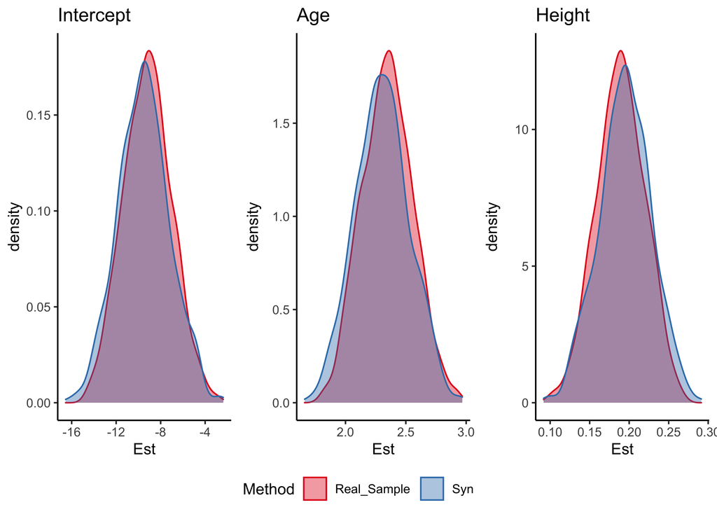

When we increase the number of synthetic datasets to $M = 20$, the coverage is actually slightly worse than in the case of $M = 10$. This seems to be due to the fact that the bias remains and the confidence interval gets slightly narrower.

| Method | Variable | Population estimate | Qbar | Bias | MeanSE | MinSE | MaxSE | Lower | Upper | CIW | Coverage |
| --- | --- | --- | --- | --- | --- | --- | --- | --- | --- | --- | --- |
| Real_Sample | (Intercept) | -9.177 | -9.177 | 0.000 | 2.041 | 1.615 | 2.402 | -13.178 | -5.177 | 8.001 | 0.938 |
| Real_Sample | age | 2.348 | 2.348 | 0.000 | 0.188 | 0.149 | 0.221 | 1.979 | 2.717 | 0.738 | 0.924 |
| Real_Sample | hgt | 0.189 | 0.189 | 0.000 | 0.028 | 0.022 | 0.033 | 0.134 | 0.244 | 0.110 | 0.932 |
| Syn | (Intercept) | -9.177 | -9.509 | -0.332 | 2.076 | 1.677 | 2.456 | -13.578 | -5.441 | 8.137 | 0.926 |
| Syn | age | 2.348 | 2.305 | -0.043 | 0.191 | 0.155 | 0.228 | 1.931 | 2.679 | 0.748 | 0.904 |
| Syn | hgt | 0.189 | 0.195 | 0.005 | 0.028 | 0.023 | 0.033 | 0.139 | 0.250 | 0.111 | 0.900 |

| Method | Variable | Population estimate | Qbar | Bias | MeanSE | MinSE | MaxSE | Lower | Upper | CIW | Coverage |
| --- | --- | --- | --- | --- | --- | --- | --- | --- | --- | --- | --- |
| Real_Sample | (Intercept) | -8.778 | -8.778 | 0.000 | 0.618 | 0.585 | 0.652 | -9.989 | -7.566 | 2.422 | 0.934 |
| Real_Sample | age | 2.352 | 2.352 | 0.000 | 0.055 | 0.052 | 0.058 | 2.244 | 2.460 | 0.217 | 0.922 |
| Real_Sample | hgt | 0.182 | 0.182 | 0.000 | 0.008 | 0.008 | 0.009 | 0.166 | 0.198 | 0.033 | 0.933 |
| Syn | (Intercept) | -8.778 | -8.717 | 0.061 | 0.648 | 0.610 | 0.684 | -9.986 | -7.447 | 2.538 | 0.931 |
| Syn | age | 2.352 | 2.358 | 0.006 | 0.058 | 0.054 | 0.061 | 2.245 | 2.472 | 0.227 | 0.915 |
| Syn | hgt | 0.182 | 0.181 | -0.001 | 0.009 | 0.008 | 0.009 | 0.164 | 0.198 | 0.034 | 0.914 |

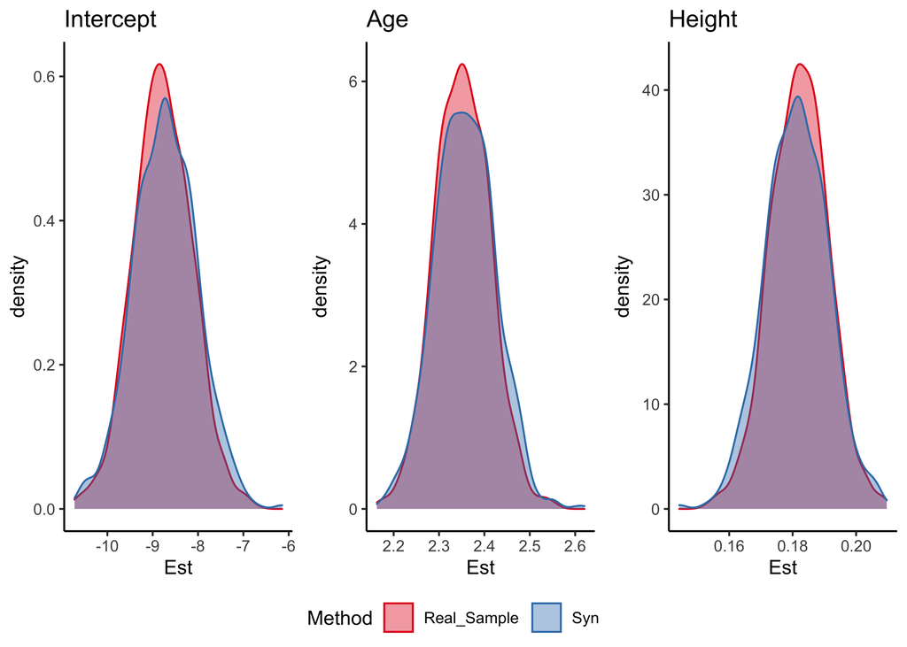

### 5.1.2 Missing data workflow

#### 5.1.2.1 IDEA

- Since synthpop messes up
5. Werken met boys data met missings.
6. Maak superpopulatie obs van bootstrappen (binnen de for-loop)
7. For i in 1:nsim (eventueel voor verschillende sample sizes):
   - Bootstrap boys data (hebben we bootstrap sample)
   - Partitioneer bootstrap sample in 5 delen
   - Synthesize each node independently from the others.
   - Merge the nodes
   - Impute the synthetic dataset as a whole
   - Subset the synthetic data so that they correspond to the observed (partitioned) data
   - Match the corresponding synthetic imputation to the observed imputation for all of the synthetic imputed sets.
8. Gemiddelde over de bootstraps is de populatiewaarde.
9. Check Qbar, bias, CI width en CI coverage van synthetische data.

### 5.1.3 IK MOET LEZEN

10. Drechsler over synthetic data
11. Over CART (Elements of Statistical Learning?)

Raab, G. M., Nowok, B., & Dibben, C. (2016). Practical Data Synthesis for Large Samples. *Journal of Privacy and Confidentiality*, *7*(3), 67–97. https://doi.org/10.29012/jpc.v7i3.407